# Principios y Prácticas de SEM y MLM (5a ed.)

Tema 0. Presentación del curso

Author

Efraín García Sánchez

Published

August 5, 2026

# Propuesta

## “Aprender a mirar”

> “Diego no conocía la mar. El padre, Santiago Kovadloff, lo llevó a descubrirla.

> Viajaron al sur.

> Ella, la mar, estaba más allá de los altos médanos, esperando.

> Cuando el niño y su padre alcanzaron por fin aquellas cumbres de arena, después de mucho caminar, la mar estalló ante sus ojos. Y fue tanta la inmensidad de la mar, y tanto su fulgor, que el niño quedó mudo de hermosura.

> Y cuando por fin consiguió hablar, temblando, tartamudeando, pidió a su padre:

> ¡Ayúdame a mirar!” (Eduardo Galeano)

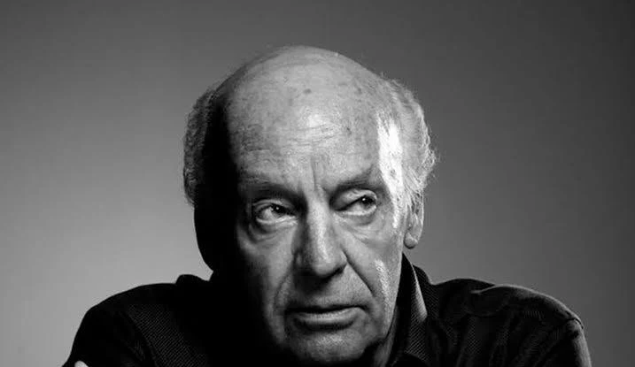

## Objetivos y propuesta general del curso

- **Principios**
  - Presentar los *fundamentos conceptuales y metodológicos* (SEM - MLM)
  - **¿Qué es?** (e.g., definiciones)
  - **¿Para qué sirve?** (e.g., aplicaciones, preguntas de investigación)
  - **¿Cómo funciona?**? (e.g., supuestos, conceptos)
- **Prácticas**
  - *Aplicar conceptos y usar herramientas*
  - ¿Cómo se **usan** o se aplican? (e.g., software, código)
  - ¿Cómo se **interpretan**? (e.g., salidas del software)
  - ¿Cómo se **reportan?** (e.g., comunicación científica)

## Propuesta metodológica del curso

**General**

- Presentaciones
- Demostraciones
- Ejercicios

**Aplicado**

- Teoría (superficial)
- Muy pocas fórmulas
- Método + software
- Fundamentos con palabras (sin pruebas matemáticas)

**Procedimientos**

- Todo es orientativo (muchas variaciones)
- Muchos supuestos (preguntas, datos, diseños, etc.)
- Campo en evolución constante (e.g., nuevas técnicas)

## Programa del curso

| Día 1 | Día 2 | Día 3 | Día 4 |
| --- | --- | --- | --- |
| **Introducción a SEM y modelos estadísticos** | **Modelos de medición** | **Modelos estructurales** | **Modelos mixtos/multinivel** |
| 1. Introducción a los modelos SEM 2. Regresión lineal 3. Moderación | 1. Análisis factorial exploratorio (EFA) 2. Análisis factorial confirmatorio (CFA) 3. Algunas extensiones de CFA | 1. Del CFA al SEM: MIMIC 2. SEM con variables latentes 3. Análisis de mediación | 1. Teoría y problemas multinivel 2. Modelo de interceptos aleatorios (*random intercepts*) 3. Modelo de pendientes aleatorias (*random slopes*) |

**TipIdea clave**

Más que memorizar conceptos, se busca **comprender globalmente** los problemas de investigación y las técnicas para resolverlos — La implementación en un software es cada vez menos relevante

## ¿Cómo sacarle el máximo provecho al curso?

- Atender el curso y ejercicios en clase
- Estudio independiente
- Compartir opiniones y preguntas (seminario entre investigadores/as)
- Desarrollar criterio para tomar decisiones (muchas excepciones y aplicaciones)
- Priorizar los principios/fundamentos (sobre las técnicas/software)
- Recordar que es un proceso (**tiempo**, esfuerzo y se hace en compañía)

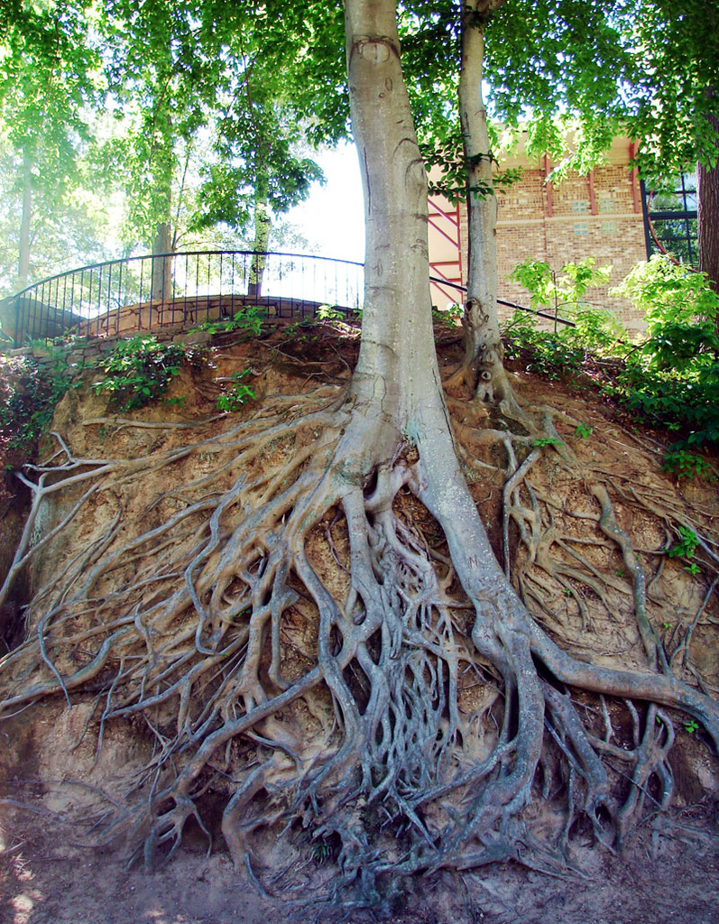